# Strategizer Package Tutorial

[output not shown]

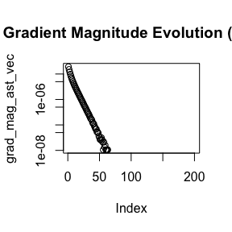

[output not shown]

[output not shown]

[output not shown]

[output not shown]

[output not shown]

[output not shown]

[output not shown]

[output not shown]

```
## Optimizing cluster 3 of 3...
```

```
## Optimization type: Gradient ascent
```

```
## SGD Iteration: 1 of 200
```

```
## SGD Iteration: 2 of 200
```

```
## SGD Iteration: 3 of 200
```

```
## SGD Iteration: 4 of 200
```

```
## SGD Iteration: 50 of 200
```

```
## SGD Iteration: 100 of 200
```

```
## SGD Iteration: 150 of 200
```

```
## SGD Iteration: 200 of 200
```

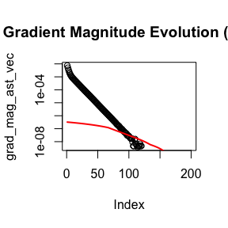

```
## SGD Iteration: 1 of 200
```

```
## SGD Iteration: 2 of 200
```

```
## SGD Iteration: 3 of 200
```

```
## SGD Iteration: 4 of 200
```

```
## SGD Iteration: 50 of 200
```

```
## SGD Iteration: 100 of 200
```

```
## SGD Iteration: 150 of 200
```

```
## SGD Iteration: 200 of 200
```

```
## strategize() call has finished...
```

[output not shown]

[output not shown]

[output not shown]

[output not shown]

```
## Preparing Data
```

```
## Computing Initalization
```

```
## Fitting MBO
```

[output not shown]

[output not shown]

[output not shown]

[output not shown]

```
## Done initializing outcome models & starting optimization sequence...
```

```
## Defining Q functions..
```

```
## Defining gd function...
```

```
## Starting optimization...
```

```
## Optimizing cluster 1 of 3...
```

```
## Optimization type: Gradient ascent
```

```
## SGD Iteration: 1 of 1
```

```
## SGD Iteration: 1 of 1
```

```
## Optimizing cluster 2 of 3...
```

```
## Optimization type: Gradient ascent
```

```
## SGD Iteration: 1 of 1
```

```
## SGD Iteration: 1 of 1
```

```
## Optimizing cluster 3 of 3...
```

```
## Optimization type: Gradient ascent
```

```
## SGD Iteration: 1 of 1
```

```
## SGD Iteration: 1 of 1
```

```
## strategize() call has finished...
```

```
## strategize() call has begun...
```

```
## Initializing outcome models...
```

```
## [1] 1 1
```

```
## ok_counter = 0
```

```
## Preparing Data
```

```
## Computing Initalization
```

```
## Fitting MBO
```

```
## [mbo] 1: l=-1.5 : y = 1.93e+03 : 0.5 secs : infill_eqi
```

```
## [mbo] 2: l=-1.6 : y = 1.93e+03 : 0.6 secs : infill_eqi
```

```
## [mbo] 3: l=-1.66 : y = 1.93e+03 : 0.6 secs : infill_eqi
```

[output not shown]

```
## Done initializing outcome models & starting optimization sequence...
```

```
## Defining Q functions..
```

```
## Defining gd function...
```

```
## Starting optimization...
```

```
## Optimizing cluster 1 of 3...
```

```
## Optimization type: Gradient ascent
```

```
## SGD Iteration: 1 of 200
```

```
## SGD Iteration: 2 of 200
```

```
## SGD Iteration: 3 of 200
```

```
## SGD Iteration: 4 of 200
```

```
## SGD Iteration: 50 of 200
```

```
## SGD Iteration: 100 of 200
```

```
## SGD Iteration: 150 of 200
```

```
## SGD Iteration: 200 of 200
```

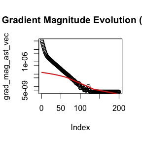

```
## SGD Iteration: 1 of 200
```

```
## SGD Iteration: 2 of 200
```

```
## SGD Iteration: 3 of 200
```

```
## SGD Iteration: 4 of 200
```

```
## SGD Iteration: 50 of 200
```

```
## SGD Iteration: 100 of 200
```

```
## SGD Iteration: 150 of 200
```

```
## SGD Iteration: 200 of 200
```

```
## Optimizing cluster 2 of 3...
```

```
## Optimization type: Gradient ascent
```

```
## SGD Iteration: 1 of 200
```

```
## SGD Iteration: 2 of 200
```

```
## SGD Iteration: 3 of 200
```

```
## SGD Iteration: 4 of 200
```

```
## SGD Iteration: 50 of 200
```

```
## SGD Iteration: 100 of 200
```

```
## SGD Iteration: 150 of 200
```

```
## SGD Iteration: 200 of 200
```

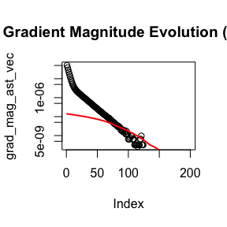

```
## SGD Iteration: 1 of 200
```

```
## SGD Iteration: 2 of 200
```

```
## SGD Iteration: 3 of 200
```

```
## SGD Iteration: 4 of 200
```

```
## SGD Iteration: 50 of 200
```

```
## SGD Iteration: 100 of 200
```

```
## SGD Iteration: 150 of 200
```

```
## SGD Iteration: 200 of 200
```

```
## Optimizing cluster 3 of 3...
```

```
## Optimization type: Gradient ascent
```

```
## SGD Iteration: 1 of 200
```

```
## SGD Iteration: 2 of 200
```

```
## SGD Iteration: 3 of 200
```

```
## SGD Iteration: 4 of 200
```

```
## SGD Iteration: 50 of 200
```

```
## SGD Iteration: 100 of 200
```

```
## SGD Iteration: 150 of 200
```

```
## SGD Iteration: 200 of 200
```

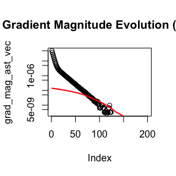

```
## SGD Iteration: 1 of 200
```

```
## SGD Iteration: 2 of 200
```

```
## SGD Iteration: 3 of 200
```

```
## SGD Iteration: 4 of 200
```

```
## SGD Iteration: 50 of 200
```

```
## SGD Iteration: 100 of 200
```

```
## SGD Iteration: 150 of 200
```

```
## SGD Iteration: 200 of 200
```

```
## strategize() call has finished...
```

```
## strategize() call has begun...
```

```
## Initializing outcome models...
```

```
## [1] 1 1
```

```
## ok_counter = 0
```

```
## Preparing Data
```

```
## Computing Initalization
```

```
## Fitting MBO
```

```
## [mbo] 1: l=-1.68 : y = 932 : 2.8 secs : infill_eqi
```

```
## [mbo] 2: l=-1.54 : y = 933 : 0.5 secs : infill_eqi
```

```
## [mbo] 3: l=-1.5 : y = 933 : 0.5 secs : infill_eqi
```

[output not shown]

```
## This large step size also occured during MBO.
```

```
## Done initializing outcome models & starting optimization sequence...
```

```
## Defining Q functions..
```

```
## Defining gd function...
```

```
## Starting optimization...
```

```
## Optimizing cluster 1 of 3...
```

```
## Optimization type: Gradient ascent
```

```
## SGD Iteration: 1 of 1
```

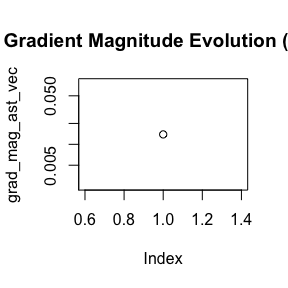

```
## SGD Iteration: 1 of 1
```

```
## Optimizing cluster 2 of 3...
```

```
## Optimization type: Gradient ascent
```

```
## SGD Iteration: 1 of 1
```

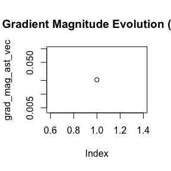

```
## SGD Iteration: 1 of 1
```

```
## Optimizing cluster 3 of 3...
```

```
## Optimization type: Gradient ascent
```

```
## SGD Iteration: 1 of 1
```

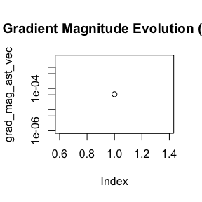

```
## SGD Iteration: 1 of 1
```

```
## strategize() call has finished...
```

```
## strategize() call has begun...
```

```
## Initializing outcome models...
```

```
## [1] 1 1
```

```
## ok_counter = 0
```

```
## Preparing Data
```

```
## Computing Initalization
```

```
## Fitting MBO
```

```
## [mbo] 1: l=-1.65 : y = 1.9e+03 : 0.4 secs : infill_eqi
```

```
## [mbo] 2: l=-1.5 : y = 1.9e+03 : 0.4 secs : infill_eqi
```

```
## [mbo] 3: l=-1.5 : y = 1.9e+03 : 0.4 secs : infill_eqi
```

[output not shown]

```
## Done initializing outcome models & starting optimization sequence...
```

```
## Defining Q functions..
```

```
## Defining gd function...
```

```
## Starting optimization...
```

```
## Optimizing cluster 1 of 3...
```

```
## Optimization type: Gradient ascent
```

[output not shown]

```
## SGD Iteration: 2 of 200
```

```
## SGD Iteration: 3 of 200
```

```
## SGD Iteration: 4 of 200
```

```
## SGD Iteration: 50 of 200
```

```
## SGD Iteration: 100 of 200
```

```
## SGD Iteration: 150 of 200
```

```
## SGD Iteration: 200 of 200
```

[output not shown]

```
## SGD Iteration: 2 of 200
```

```
## SGD Iteration: 3 of 200
```

```
## SGD Iteration: 4 of 200
```

```
## SGD Iteration: 50 of 200
```

```
## SGD Iteration: 100 of 200
```

```
## SGD Iteration: 150 of 200
```

```
## SGD Iteration: 200 of 200
```

```
## Optimizing cluster 2 of 3...
```

```
## Optimization type: Gradient ascent
```

```
## SGD Iteration: 1 of 200
```

```
## SGD Iteration: 2 of 200
```

```
## SGD Iteration: 3 of 200
```

```
## SGD Iteration: 4 of 200
```

```
## SGD Iteration: 50 of 200
```

```
## SGD Iteration: 100 of 200
```

```
## SGD Iteration: 150 of 200
```

```
## SGD Iteration: 200 of 200
```

```
## SGD Iteration: 1 of 200
```

```
## SGD Iteration: 2 of 200
```

```
## SGD Iteration: 3 of 200
```

```
## SGD Iteration: 4 of 200
```

```
## SGD Iteration: 50 of 200
```

```
## SGD Iteration: 100 of 200
```

```
## SGD Iteration: 150 of 200
```

```
## SGD Iteration: 200 of 200
```

```
## Optimizing cluster 3 of 3...
```

```
## Optimization type: Gradient ascent
```

```
## SGD Iteration: 1 of 200
```

```
## SGD Iteration: 2 of 200
```

```
## SGD Iteration: 3 of 200
```

```
## SGD Iteration: 4 of 200
```

```
## SGD Iteration: 50 of 200
```

```
## SGD Iteration: 100 of 200
```

```
## SGD Iteration: 150 of 200
```

```
## SGD Iteration: 200 of 200
```

```
## SGD Iteration: 1 of 200
```

```
## SGD Iteration: 2 of 200
```

```
## SGD Iteration: 3 of 200
```

```
## SGD Iteration: 4 of 200
```

```
## SGD Iteration: 50 of 200
```

```
## SGD Iteration: 100 of 200
```

```
## SGD Iteration: 150 of 200
```

```
## SGD Iteration: 200 of 200
```

```
## strategize() call has finished...
```

```
## strategize() call has begun...
```

```
## Initializing outcome models...
```

```
## [1] 1 1
```

```
## ok_counter = 0
```

```
## Preparing Data
```

```
## Computing Initalization
```

```
## Fitting MBO
```

```
## [mbo] 1: l=-1.5 : y = 969 : 0.4 secs : infill_eqi
```

```
## [mbo] 2: l=-1.66 : y = 969 : 0.4 secs : infill_eqi
```

```
## [mbo] 3: l=-1.58 : y = 969 : 0.3 secs : infill_eqi
```

[output not shown]

```
## This large step size also occured during MBO.
```

```
## Done initializing outcome models & starting optimization sequence...
```

```
## Defining Q functions..
```

```
## Defining gd function...
```

```
## Starting optimization...
```

```
## Optimizing cluster 1 of 3...
```

```
## Optimization type: Gradient ascent
```

```
## SGD Iteration: 1 of 1
```

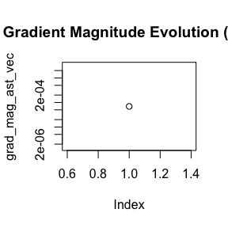

```
## SGD Iteration: 1 of 1
```

```
## Optimizing cluster 2 of 3...
```

```
## Optimization type: Gradient ascent
```

```
## SGD Iteration: 1 of 1
```

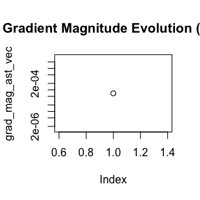

```
## SGD Iteration: 1 of 1
```

```
## Optimizing cluster 3 of 3...
```

```
## Optimization type: Gradient ascent
```

```
## SGD Iteration: 1 of 1
```

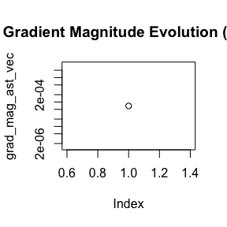

```
## SGD Iteration: 1 of 1
```

```
## strategize() call has finished...
```

[output not shown]

```
## strategize() call has begun...
```

```
## Initializing outcome models...
```

```
## [1] 1 1
```

```
## ok_counter = 0
```

```
## Preparing Data
```

```
## Computing Initalization
```

```
## Fitting MBO
```

```
## [mbo] 1: l=-1.5 : y = 2.82e+03 : 0.4 secs : infill_eqi
```

```
## [mbo] 2: l=-1.5 : y = 2.82e+03 : 0.4 secs : infill_eqi
```

```
## [mbo] 3: l=-1.57 : y = 2.82e+03 : 0.5 secs : infill_eqi
```

[output not shown]

```
## Done initializing outcome models & starting optimization sequence...
```

```
## Defining Q functions..
```

```
## Defining gd function...
```

```
## Starting optimization...
```

```
## Optimizing cluster 1 of 3...
```

```
## Optimization type: Gradient ascent
```

[output not shown]

```
## SGD Iteration: 2 of 200
```

```
## SGD Iteration: 3 of 200
```

```
## SGD Iteration: 4 of 200
```

```
## SGD Iteration: 50 of 200
```

```
## SGD Iteration: 100 of 200
```

```
## SGD Iteration: 150 of 200
```

```
## SGD Iteration: 200 of 200
```

[output not shown]

```
## SGD Iteration: 2 of 200
```

```
## SGD Iteration: 3 of 200
```

```
## SGD Iteration: 4 of 200
```

```
## SGD Iteration: 50 of 200
```

```
## SGD Iteration: 100 of 200
```

```
## SGD Iteration: 150 of 200
```

```
## SGD Iteration: 200 of 200
```

```
## Computing SEs...
```

[output not shown]

```
## SGD Iteration: 2 of 200
```

```
## SGD Iteration: 3 of 200
```

```
## SGD Iteration: 4 of 200
```

```
## SGD Iteration: 50 of 200
```

```
## SGD Iteration: 100 of 200
```

```
## SGD Iteration: 150 of 200
```

```
## SGD Iteration: 200 of 200
```

```
## Optimizing cluster 2 of 3...
```

```
## Optimization type: Gradient ascent
```

[output not shown]

```
## SGD Iteration: 2 of 200
```

```
## SGD Iteration: 3 of 200
```

```
## SGD Iteration: 4 of 200
```

```
## SGD Iteration: 50 of 200
```

```
## SGD Iteration: 100 of 200
```

```
## SGD Iteration: 150 of 200
```

```
## SGD Iteration: 200 of 200
```

```
## SGD Iteration: 1 of 200
```

```
## SGD Iteration: 2 of 200
```

```
## SGD Iteration: 3 of 200
```

```
## SGD Iteration: 4 of 200
```

```
## SGD Iteration: 50 of 200
```

```
## SGD Iteration: 100 of 200
```

```
## SGD Iteration: 150 of 200
```

```
## SGD Iteration: 200 of 200
```

```
## Computing SEs...
```

[output not shown]

```
## SGD Iteration: 2 of 200
```

```
## SGD Iteration: 3 of 200
```

```
## SGD Iteration: 4 of 200
```

```
## SGD Iteration: 50 of 200
```

```
## SGD Iteration: 100 of 200
```

```
## SGD Iteration: 150 of 200
```

```
## SGD Iteration: 200 of 200
```

```
## Optimizing cluster 3 of 3...
```

```
## Optimization type: Gradient ascent
```

[output not shown]

```
## SGD Iteration: 2 of 200
```

```
## SGD Iteration: 3 of 200
```

```
## SGD Iteration: 4 of 200
```

```
## SGD Iteration: 50 of 200
```

```
## SGD Iteration: 100 of 200
```

```
## SGD Iteration: 150 of 200
```

```
## SGD Iteration: 200 of 200
```

```
## SGD Iteration: 1 of 200
```

```
## SGD Iteration: 2 of 200
```

```
## SGD Iteration: 3 of 200
```

```
## SGD Iteration: 4 of 200
```

```
## SGD Iteration: 50 of 200
```

```
## SGD Iteration: 100 of 200
```

```
## SGD Iteration: 150 of 200
```

```
## SGD Iteration: 200 of 200
```

```
## Computing SEs...
```

[output not shown]

```
## SGD Iteration: 2 of 200
```

```
## SGD Iteration: 3 of 200
```

```
## SGD Iteration: 4 of 200
```

```
## SGD Iteration: 50 of 200
```

```
## SGD Iteration: 100 of 200
```

```
## SGD Iteration: 150 of 200
```

```
## SGD Iteration: 200 of 200
```

```
## strategize() call has finished...
```

```
## Done with strategic analysis!
```

```r
# Inspect results:
res_clust$PiStar_point     # The learned factor-level distribution(s)
```

[output not shown]

```r
res_clust$Q_point_mEst     # The estimated performance or outcome
```

```
##        k1        k2        k3
## 0.4899998 0.4899998 0.4899998
```

```r
res_clust$PiStar_se        # Standard errors (if compute_se=TRUE)
```

[output not shown]

```r
res_clust$Q_se_mEst
```

```
##        k1        k2        k3
## 0.0111781 0.0111781 0.0111781
```

# Advanced Topics

Additional advanced functionalities include:

- `use_regularization = TRUE` if you want *both* the distribution itself *and* the outcome model to be regularized (especially for many factors).
- `slate_list` to restrict certain factors (like if you have a known set of feasible factor-level combos in a candidate primary).
- Cluster-based expansions for multi-cluster designs, specifying `K > 1` for a mixture approach.

## Conclusion

This vignette has illustrated the core usage of the `strategize` package for:

1. Defining factor-level assignment probabilities (the original design).
2. Fitting an outcome model or passing your own model estimates.
3. Optimizing to find an *average-case* or *adversarial* (max-min) solution for a new factor-level distribution.
4. Interpreting the estimated solution, e.g., the new distribution that up- or down-weights certain levels.

We hope this helps you investigate questions of *optimal* or *adversarial* design in conjoint experiments, bridging policy learning and typical factorial designs. Please see the documentation of `strategize`, `cv_strategize`, and `strategize_onestep` for additional arguments and more advanced use-cases.